# Compte-Rendu PMS - Ensimag 2025

2025-04-02

# Partie I

## Q1

On sait que pour une loi uniforme discrète de paramètres (1,$\theta$),

$E(X) =\frac{\theta +1}{2}$

$V(X) = \frac{\theta^2 -1}{12}$

## Q2

D’après la question précédente,

$$\begin{align*}
\tilde{\theta}_n & = 2\bar{X}_n - 1 \\
E(\bar{X}n) & = E\left(\frac{1}{n}\sum_{k=1}^{n}X_k\right) \\
& = \frac{n}{n}E(X_1) \\
& = \frac{\theta + 1}{2} \\
E(\tilde{\theta}_n) & = 2E(\bar{X}_n) - 1 \\
& = 2\left(\frac{\theta + 1}{2}\right) - 1 \\
& = \theta
\end{align*}$$

Donc l’estimateur est sans biais. De même :

$$\begin{align*}
V(\tilde{\theta}_n) &= 4V(\bar{X_n})\\
& =\frac{4n}{n^2}V(\bar{X}) \\
& = \frac{4}{n}\frac{\theta^2 -4}{12} \\
& =\frac{\theta^2 -1}{3n} \\
\end{align*}$$

par indépendance des variables aléatoires.

## Q3

$\forall t, F_X(t) = \frac{\lceil t \rceil}{\theta}\mathbf{1}_{1, \theta}$

$F_X(k)=\frac{1}{2} \Leftrightarrow k = \lceil \frac{\theta}{2} \rceil$

On en déduit : $\tilde{\theta}'_n =2\bar{M_n}$

## Q4

$F_{X_n^*}(t) = P(\bigcap_{i=1}^{n}(X_i\leqslant t)) = \prod_{i=1}^{n}\frac{\lceil t \rceil}{\theta} = (\frac{\lceil t \rceil}{\theta})^n$

$P(X_n^*=k ; \theta) = P(X_n^*\leqslant k ; \theta) - P(X_n^*\leqslant k-1 ; \theta) = (\frac{k}{\theta})^n -(\frac{k-1}{\theta})^n$ par indépendance des variables aléatoires.

## Q5

On sait que $P(X_n^*=k_1,...,X_n=k_n) ; \theta) = \frac{1}{\theta^n}\mathbf{1}_{[1, \theta]^n}$ par indépendance des lois.

Si $\theta < \max(k_i)$, alors cette probabilité est nulle à cause de la fonction caractéristique. Donc $\hat{\theta} \geqslant X_n^*$ et comme il faut minimiser cette grandeur pour maximiser la probabilité, $\hat{\theta} = X_n^*$.

On a $\forall i, X_i \leqslant \theta$ avec $P(X_i<\theta) > 0$ Donc en moyenne, $X_n^* < \theta$ i.e $E(X_n^*) < \theta$.

## Q6

On a $F_{X}(x_i^*)=\frac{x_i*}{\theta} \approx \frac{i}{n}$ On trace le nuage $(x_i^*,\frac{i}{n})_i$ et on doit avoir une droite de pente $\frac{1}{\theta}$ $\theta_g$ est donc l’inverse du coefficient directeur après linéarisation (avec la méthode des moindres carrés par exemple).

## Q7

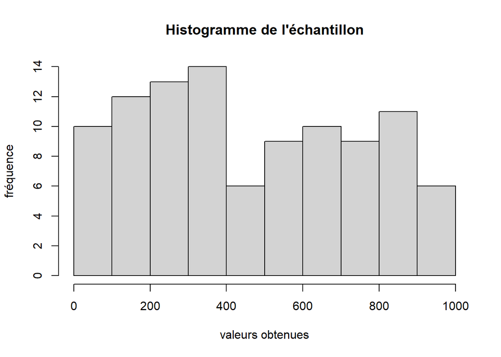

```r
n <- 100
theta <- 1000
echantillon_7 <- sample(1:theta, n, replace = TRUE)
hist(echantillon_7, main="Histogramme de l'échantillon", xlab="valeurs obtenues", ylab = "fréquence")
```

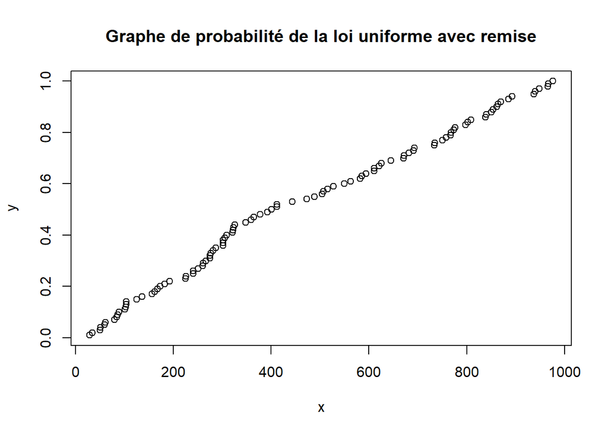

```r
x=sort(echantillon_7)
y=(1:n)/n

plot(x,y, main="Graphe de probabilité de la loi uniforme avec remise")
```

```r
modele <- lm(y ~ x)
```

Estimation graphique :

```r
1/coefficients(modele)[2]
```

```
##        x
## 987.8707
```

Estimation par moyenne empirique :

```r
2*mean(x)-1
```

```
## [1] 927.04
```

Estimation par médiane :

```r
2*median(x)
```

```
## [1] 813
```

Estimation par maximum de vraisemblance :

```r
max(x)
```

```
## [1] 976
```

Estimation ESBVM donnée dans l’énoncé :

```r
(max(x)^(n+1)-(max(x)-1)^{n+1})/(max(x)^(n)-(max(x)-1)^{n})
```

```
## [1] 985.2635
```

## Q8

```r
m= 100
n <- 100
ech_1=c()
ech_2=c()
ech_3=c()
ech_4=c()
ech_5=c()
for (k in 1:m){
theta <- 1000
echantillon <- sample(1:theta, n, replace = TRUE)
x=sort(echantillon)
y=(1:n)/n
modele <- lm(y ~ x)
ech_1[k]=1/coefficients(modele)[2]
ech_2[k]=2*mean(x)-1
ech_3[k]=2*median(x)
ech_4[k]=max(x)
ech_5[k]=(max(x)^(n+1)-(max(x)-1)^{n+1})/(max(x)^(n)-(max(x)-1)^{n})}
```

Biais moyen méthode graphique :

```r
mean(ech_1)-theta
```

```
## [1] -7.429575
```

Biais moyen moyenne empirique :

```r
mean(ech_2)-theta
```

```
## [1] -14.0976
```

Biais moyen médiane:

```r
mean(ech_3)-theta
```

```
## [1] -6.87
```

Biais moyen maximum de vraisemblance :

```r
mean(ech_4)-theta
```

```
## [1] -10.43
```

Biais moyen ESBVM:

```r
mean(ech_5)-theta
```

```
## [1] -1.030876
```

EQM méthode graphique :

```r
mean((ech_1-theta)*2)
```

```
## [1] -14.85915
```

EQM moyenne empirique

```r
mean((ech_2-theta)*2)
```

```
## [1] -28.1952
```

EQM médiane :

```r
mean((ech_3-theta)*2)
```

```
## [1] -13.74
```

EQM maximum de vraisemblance :

```r
mean((ech_4-theta)*2)
```

```
## [1] -20.86
```

EQM ESBVM :

```r
mean((ech_5-theta)*2)
```

```
## [1] -2.061752
```

## Q9

D’après le théorème central limite on a $\bar{X_n} \xrightarrow{L} \mathcal{N}(\mu, \frac{\sigma^2}{n})$ où $\mu = E(X)$ Donc d’après le théorème de Fisher on peut écrire asymptotiquement :

$\sqrt{n-1}\frac{\bar{X_n} - \mu}{S_n} \xrightarrow{L} St(n-1)$ où $S_n$ est l’écart-type empirique des $X_i$.

On cherche donc $\epsilon$ pour un intervalle bilatéral vérifiant asymptotiquement :

$P(\bar{X_n} - \epsilon\leqslant \mu \leqslant \bar{X_n} + \epsilon) = 1-\alpha$ c’est à dire :

$P(\frac{\sqrt{n-1}}{{S_n}}(\bar{X_n} - \epsilon)\leqslant \mu \frac{\sqrt{n-1}}{{S_n}}\leqslant \frac{\sqrt{n-1}}{{S_n}}(\bar{X_n} + \epsilon)) = 1- \alpha$  
Ce qui est vérifié pour $\epsilon = \frac{q_{\alpha}S_n}{\sqrt{n-1}}$ où $q_i$ est le quantile d’ordre i de la loi de Student de paramètre $n-1$. On a donc :

$\lim_{n \rightarrow \infty} P(\mu \in [\bar{X_n} - \frac{q_{\alpha}S_n}{\sqrt{n-1}} ; \bar{X_n} + \frac{q_{\alpha}S_n}{\sqrt{n-1}} ])=1-\alpha$ et avec $\theta = 2\mu -1$ il vient :

$I_n = [2(\bar{X_n} - \frac{q_{\alpha}S_n}{\sqrt{n-1}}) -1 ; 2(\bar{X_n} + \frac{q_{\alpha}S_n}{\sqrt{n-1}}) -1 ]$

Calcul avec l’echantillon précédent :

```r
moyenne=mean(echantillon_7)
alpha=0.05
quantile=qt(1-alpha/2,n-1)
ecart_type=sqrt(var(echantillon_7))


borne_inf = 2*(moyenne - (quantile*ecart_type)/sqrt(n-1))-1
borne_sup = 2*(moyenne + (quantile*ecart_type)/sqrt(n-1))-1
```

Borne inférieure :

```r
borne_inf
```

```
## [1] 813.3966
```

Borne supérieure:

```r
borne_sup
```

```
## [1] 1040.683
```

## Q10

Pour $n$=10 :

```r
m=1000
tot=0
n=10
for(k in 1:m){
echantillon <- sample(1:theta, n, replace = TRUE)
moyenne=mean(echantillon)
alpha=0.05
quantile=qt(1-alpha/2,n-1)
ecart_type=sqrt(var(echantillon))


borne_inf = 2*(moyenne - (quantile*ecart_type)/sqrt(n-1))-1
borne_sup = 2*(moyenne + (quantile*ecart_type)/sqrt(n-1))-1

if(borne_inf<theta && theta<borne_sup){
  tot=tot+1}

}
```

Proportion :

```r
tot/m
```

```
## [1] 0.95
```

Pour $n$=1000 :

```r
m=1000
tot=0
n=1000
for(k in 1:m){
echantillon <- sample(1:theta, n, replace = TRUE)
moyenne=mean(echantillon)
alpha=0.05
quantile=qt(1-alpha/2,n-1)
ecart_type=sqrt(var(echantillon))


borne_inf = 2*(moyenne - (quantile*ecart_type)/sqrt(n-1))-1
borne_sup = 2*(moyenne + (quantile*ecart_type)/sqrt(n-1))-1

if(borne_inf<theta && theta<borne_sup){
  tot=tot+1}

}
```

Proportion:

```r
tot/m
```

```
## [1] 0.95
```

Pour $\theta$=10:

```r
theta=10
m=1000
tot=0
n=1000
for(k in 1:m){
echantillon <- sample(1:theta, n, replace = TRUE)
moyenne=mean(echantillon)
alpha=0.05
quantile=qt(1-alpha/2,n-1)
ecart_type=sqrt(var(echantillon))


borne_inf = 2*(moyenne - (quantile*ecart_type)/sqrt(n-1))-1
borne_sup = 2*(moyenne + (quantile*ecart_type)/sqrt(n-1))-1

if(borne_inf<theta && theta<borne_sup){
  tot=tot+1}

}
```

Proportion:

```r
tot/m
```

```
## [1] 0.956
```

La proportion d’intervalles de confiance contenant bien la vraie valeur de $\theta$ est bien proche de 0.95 pour $n$ et $\theta$ petits comme grands.

# Partie II

## Q1

Déterminer la loi de $X_1$, puis celle de $X_2$ sachant $[X_1 = x_1]$, puis celle de $X_3$ sachant $[X_1 = x_1, X_2=x_2]$, etc… Etant donné que la fonction de vraisemblance peut s’écrire
$$\begin{eqnarray*}
{\cal L}(\theta ; x_1, \ldots, x_n) &=& P(X_1 = x_1, \ldots
X_n=x_n ; \theta) \\
&=& P(X_1 = x_1 ; \theta) \prod_{i=2}^n P(X_i = x_i | X_1 = x_1,
\ldots X_{i-1}=x_{i-1} ; \theta),
\end{eqnarray*}$$
montrer que l’estimateur de maximum de vraisemblance de $\theta$ est toujours $\hat{\theta}_n=X_n^*$.

$X_1$ est toujours de loi uniforme (discrète) sur {1, …, θ}, ${\cal U}_{\{1,\ldots,\theta\}}$, puisqu’aucun objet n’a encore été tiré.

Par contre, la loi de de $X_2$ sachant $[X_1 = x_1]$ n’est plus une loi uniforme sur {1, …, θ} mais sur $A_2$={1, …, θ}/{$x_1$}, et $P(X_2 = x_2 | X_1 = x_1)=\frac{nombre \, d'objets \, tirés}{nombre \, d'objets \, à \, tirer}=\frac{1}{\theta-1}$ si $x_1$ est dans {1, …, θ} et $x_2$ dans $A_2$, puisqu’on effectue un tirage uniforme dans un ensemble de $\theta$-1 éléments connus (car on sait que le premier objet tiré est $x_1$).

De même, la loi de $X_3$ sachant $[X_1 = x_1, X_2=x_2]$ est une loi uniforme sur $A_3$={1, …, θ}/{$x_1, x_2$} et $P(X_3 = x_3 | X_1 = x_1, X_2 = x_2)=\frac{1}{\theta-2}$.

De manière plus générale, $P(X_i = x_i | X_1 = x_1, \ldots X_{i-1}=x_{i-1} ; \theta) = \frac{1}{\theta-i+1}$ si $\forall k, x_k$ est dans $A_k$ et la loi de de $X_2$ sachant $[X_1 = x_1, \ldots X_{i-1}=x_{i-1}]$ est la loi uniforme sur $A_i$={1, …, θ}/{$x_1, \ldots , x_{i-1}$}.

Donc si $\forall k, x_k$ est dans $A_k$ donc max($x_i) \leq \theta$ :
$${\cal L}(\theta ; x_1, \ldots, x_n) = P(X_1 = x_1
; \theta) \prod_{i=2}^n P(X_i = x_i | X_1 = x_1, \ldots X_{i-1}=x_{i-1})
= \frac{1}{\theta}*\prod_{i=2}^n
\frac{1}{\theta-i+1}=\frac{1}{\theta}*\frac{1}{\theta-1}* \ldots
*\frac{1}{\theta-n+1}.$$
Sinon, ${\cal L}(\theta ; x_1, \ldots, x_n) = 0.$

Le maximum de cette fonction est atteint quand $\theta$ est minimum, donc comme max($x_i) \leq \theta$, il est atteint pour $\theta = max(x_i) = X^*_n$ donc $\hat{\theta}_n=X_n^*$.

## Q2

Montrer que $\forall k \in \{n,\ldots,\theta\}$, $P(X_n^*=k) = {\frac{\left(_{n-1}^{k-1} \right)}{\left(_{n}^{\theta} \right)}}$. Calculer $E[X_n^*]$ et en déduire que $\hat{\theta}_n^{(1)}={\frac{n+1}{n}X_n^*-1}$ est un estimateur sans biais de $\theta$.

$$P(X_n^*=k)=\frac{nombre \, de \,
combinaisons \, de \, chars \, pour \, lesquelles \, X^*_n = k \, pour
\, n \, chars \, observés \, parmis \, \theta \, chars \,
construits}{nombre \, de \, combinaisons \, de \, chars \, possibles \,
pour \, n \, chars \, observés \, parmis \, \theta \, chars \,
construits}$$
Pour que $X_n^*=k$, il faut que la combinaison contienne exactement un élément égal à k (ce sera le maximum), et tous les autres numéros de la combinaison doivent être strictement inférieurs à k. Ainsi, il y a $\left(_{n-1}^{k-1} \right)$ choix possibles, puisqu’on doit fixer un $x_i$ égal à k puis choisir les n-1 autres numéros parmi les k−1 numéros possibles qui sont strictement inférieurs à k. Comme il y a $\left(_{n}^{\theta} \right)$ façons de répartir n numéros observés parmis $\theta$ numéros possibles, on obtient bien :

$$P(X_n^*=k)=\frac{\left(_{n-1}^{k-1}
\right)}{\left(_{n}^{\theta} \right)}.$$
Comme le numéro maximum d’une combinaison doit être compris entre le nombre de chars (puisqu’il n’y a pas de remise) et le nombre total de chars produit, si $k \notin \{n,\ldots,\theta\}$, $P(X_n^*=k) = 0.$ Donc, selon la formule d’itération de Pascal ($\sum_{k=n}^{\theta}\left(_{n}^{k} \right) = \left(_{\theta+1}^{n+1} \right)$)

$$E[X^*_n] = \sum_{k=n}^{\theta}
k*P(X_n^*=k)=\sum_{k=n}^{\theta} k*\frac{\left(_{n-1}^{k-1}
\right)}{\left(_{n}^{\theta} \right)}=\sum_{k=n}^{\theta}
k*\frac{(k-1)!}{(n-1)!(k-n)!}*\frac{n!(\theta-n)!}{\theta!}=n*\frac{n!(\theta-n)!}{\theta!}*\sum_{k=n}^{\theta}\left(_{n}^{k}
\right)=n*\frac{n!(\theta-n)!}{\theta!}*\left(_{\theta+1}^{n+1}
\right)=\frac{n}{n+1}*(\theta+1).$$
Donc $X^*_n$ est un estimateur biaisé de $\theta$. Et $E[\hat{\theta}_n^{(1)}]=\frac{n+1}{n}E[X_n^*] - 1 = \theta.$ Donc $\hat{\theta}_n^{(1)}$ est un estimateur sans biais de $\theta$.

## Q3

```
## Variance de EMV: 187.0639
## Variance de EMVSB: 269.3721
## Variance de ESYM: 422.1244
## Variance de Eremise': 269.336
## Moyenne des biais de EMV: -16.127
## Moyenne des biais de EMVSB: -0.3524
## Moyenne des biais de ESYM: -1.236
## Moyenne des biais de Eremise': 0.05257749
```

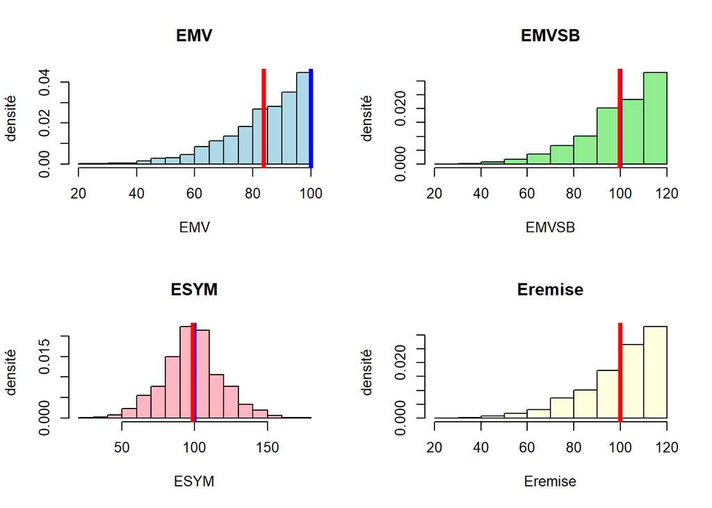

```r
BiaisChars <- function(m, n, theta){

  # Génération des échantillons correctement
  Echantillons <- replicate(m, sample(1:theta, n, replace = FALSE))

  # Calcul des estimateurs
  Xn <- apply(Echantillons, 2, max)  # Maximum de chaque échantillon
  X1 <- apply(Echantillons, 2, min)  # Minimum de chaque échantillon

  EMV <- Xn
  EMVSB <- (n + 1) / n * Xn - 1
  ESYM <- Xn + X1 - 1
  Eremise <- (Xn^(n + 1) - (Xn - 1)^(n + 1)) / (Xn^n - (Xn - 1)^n)

  # Moyennes des estimateurs
  moy_EMV <- mean(EMV)
  moy_EMVSB <- mean(EMVSB)
  moy_ESYM <- mean(ESYM)
  moy_Eremise <- mean(Eremise)

  # Calcul du biais empirique
  biais_theta0 <- mean(EMV - theta)
  biais_theta1 <- mean(EMVSB - theta)
  biais_theta2 <- mean(ESYM - theta)
  biais_Eremise <- mean(Eremise - theta)

  # Calcul des variances des estimateurs
  var_theta0 <- var(EMV)
  var_theta1 <- var(EMVSB)
  var_theta2 <- var(ESYM)
  var_theta_prime <- var(Eremise)

  cat("Variance de EMV:", var_theta0, "\n")
  cat("Variance de EMVSB:", var_theta1, "\n")
  cat("Variance de ESYM:", var_theta2, "\n")
  cat("Variance de Eremise':", var_theta_prime, "\n")

  # Affichage des résultats
  cat("Moyenne des biais de EMV:", biais_theta0, "\n")
  cat("Moyenne des biais de EMVSB:", biais_theta1, "\n")
  cat("Moyenne des biais de ESYM:", biais_theta2, "\n")
  cat("Moyenne des biais de Eremise':", biais_Eremise, "\n")

  # Histogrammes
  par(mfrow = c(2,2))
  hist(EMV, probability = TRUE, main = "EMV", col = "lightblue", ylab="densité")
  abline(v = theta, col = "blue", lwd = 4)
  abline(v = moy_EMV, col = "red", lwd = 4)

  hist(EMVSB, probability = TRUE, main = "EMVSB", col = "lightgreen", ylab="densité")
  abline(v = theta, col = "blue", lwd = 4)
  abline(v = moy_EMVSB, col = "red", lwd = 4)

  hist(ESYM, probability = TRUE, main = "ESYM", col = "lightpink", ylab="densité")
  abline(v = theta, col = "blue", lwd = 4)
  abline(v = moy_ESYM, col = "red", lwd = 4)

  hist(Eremise, probability = TRUE, main = "Eremise", col = "lightyellow", ylab="densité")
  abline(v = theta, col = "blue", lwd = 4)
  abline(v = moy_Eremise, col = "red", lwd = 4)
}

# Exécuter la fonction pour plusieurs valeurs de n
BiaisChars(1000, 5, 100)
```

```r
BiaisChars(1000, 10, 100)
```

```
## Variance de EMV: 64.04699
## Variance de EMVSB: 77.49686
## Variance de ESYM: 127.1018
## Variance de Eremise': 77.48029
## Moyenne des biais de EMV: -8.416
## Moyenne des biais de EMVSB: -0.2576
## Moyenne des biais de ESYM: -0.312
## Moyenne des biais de Eremise': 0.2015384
```

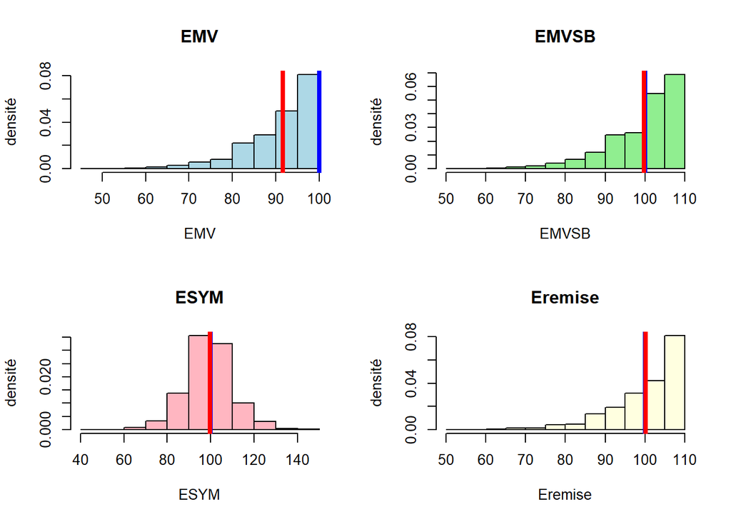

```r
BiaisChars(1000, 99, 100)
```

```
## Variance de EMV: 0.003987988
## Variance de EMVSB: 0.00406896
## Variance de ESYM: 0.01397798
## Variance de Eremise': 0.004062508
## Moyenne des biais de EMV: -0.004
## Moyenne des biais de EMVSB: 0.006060606
## Moyenne des biais de ESYM: 0.006
## Moyenne des biais de Eremise': 0.5825835
```

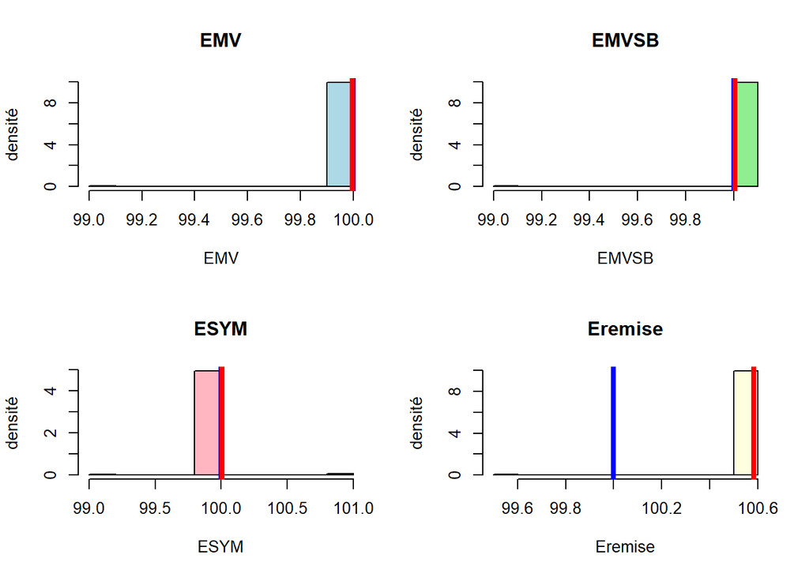

```r
BiaisChars(1000, 90, 100)
```

```
## Variance de EMV: 0.1056967
## Variance de EMVSB: 0.1080586
## Variance de ESYM: 0.2169279
## Variance de Eremise': 0.107901
## Moyenne des biais de EMV: -0.097
## Moyenne des biais de EMVSB: 0.01303333
## Moyenne des biais de ESYM: 0.017
## Moyenne des biais de Eremise': 0.5819091
```

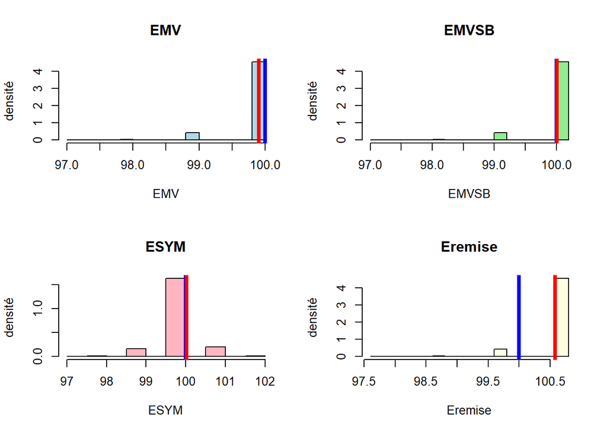

On peut voir que l’EMV est biaisé , ainsi que l’estimateur de l’exercice 1 (avec remise) pour un nombre de tirages proche du nombre réel de tanks (de plus il est incalculable pour un n trop grand à cause des puissances). Les deux autres estimateurs sont sans biais. Cependant, l’estimateur $\hat{\theta}_n^{(2)}$ a une variance bien plus grande donc l’estimateur EMVSB est meilleur.

## Q4

Avec le meilleur estimateur avec remise, lorsque le nombre de tirages se rapproche du nombre réel de tanks, un biais apparaît même si la variance reste comparable à l’EMVSB. Il n’est donc pas adapté à toutes les situations (d’autant qu’il est inutilisable pour n grand).

# Partie III

## Q1

```r
iPhones<-read.table("iPhones.csv", sep=";", header=T)
names(iPhones)
```

```
## [1] "IMEI" "PC"
```

```r
attach(iPhones)

liste_IMEI <- iPhones[, "IMEI"]

extraire_liste_numeros_serie = function(liste_IMEI){
  res = c()
  for (IMEI in liste_IMEI){

    code_TAC = as.numeric(substring(IMEI, 3, 8))
    if (code_TAC == 161200){
      numero_TAC = 1
    }else if (code_TAC == 161300){
      numero_TAC = 2
    }else if (code_TAC == 161400){
      numero_TAC = 3
    }else if (code_TAC == 171200){
      numero_TAC = 4
    }else if (code_TAC == 171300){
      numero_TAC = 5
    }else if (code_TAC == 171400){
      numero_TAC = 6
    }else if (code_TAC == 174200){
      numero_TAC = 7
    }else if (code_TAC == 174300){
      numero_TAC = 8
    }else if (code_TAC == 174400){
      numero_TAC = 9
    }else if (code_TAC == 177100){
      numero_TAC = 10
    }else if (code_TAC == 177300){
      numero_TAC = 11
    }else if (code_TAC == 177400){
      numero_TAC = 12
    }else if (code_TAC == 177500){
      numero_TAC = 13
    }else if (code_TAC == 177600){
      numero_TAC = 14
    }else if (code_TAC == 180900){
      numero_TAC = 15
    }else{
      print("code TAC non reconnu")
    }

    SNR = (as.numeric(substring(IMEI, 9, 13)) * 10)
    res = c((numero_TAC-1)*10^(6) + SNR, res)
  }
  return(res)
}
liste_numeros_serie = extraire_liste_numeros_serie(liste_IMEI)
```

On possède maintenant une fonction capable d’extraire les numéros de série peu importe l’échantillon d’IMEI donné.

## Q2

```r
estimateur = function(liste_num_serie){
  n = length(liste_num_serie)
  x=sort(liste_num_serie)
  Xn=max(x)
  X1=min(x)
  ESYM <- Xn + X1 - 1
  EMVSB <- (n + 1) / n * Xn - 1
  y=(1:n)/n
  modele <- lm(y ~ x)
  return(c(1/coefficients(modele)[2],EMVSB,ESYM))
}

res = estimateur(liste_numeros_serie)

cat("Par estimateur graphique : ", res[1], "\nPar maximum de vraisemblance sans biais : ", res[2], "\nPar estimateur symétrique : ", res[3])
```

```
## Par estimateur graphique :  16674414
## Par maximum de vraisemblance sans biais :  14887670
## Par estimateur symétrique :  14796139
```

On estime qu’environ 14,8 millions d’iPhones ont été produits durant la période concernée avec les estimateurs sans biais. Et 16,7 millions pour l’estimateur graphique avec remise.

Il est intéressant de se poser la question du choix de l’estimateur dans la mesure où la non complétude des IMEI crée la possibilité de tirer plusieurs fois le même numéro de série, simulant une sorte de tirage avec remise.

## Q3

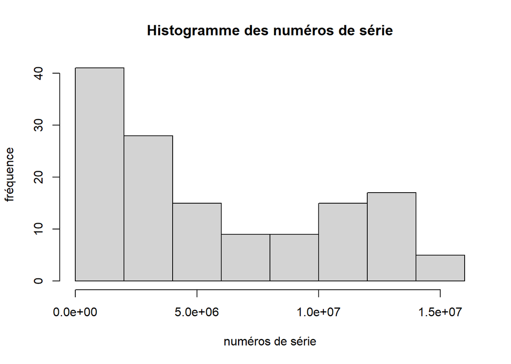

```r
hist(liste_numeros_serie, main="Histogramme des numéros de série", ylab="fréquence", xlab="numéros de série")
```

L’histogramme de la liste des numéros de série ne semble pas correspondre à une loi uniforme.

## Q4

```r
#on crée les différentes catégories par tranches de 4 semaines

groupe_825_828 = c()
groupe_829_832 = c()
groupe_833_836 = c()
groupe_837_840 = c()
groupe_841_844 = c()
groupe_845_848 = c()
groupe_849_852 = c()
groupe_901_904 = c()

liste_IMEI = iPhones[, "IMEI"]
liste_PC = iPhones[, "PC"]
n = length(liste_IMEI)

for (i in 1:n){
  date_prod = as.numeric(substring(liste_PC[i], 3, 5))
  if (date_prod >= 825 && date_prod <= 828) {
    groupe_825_828 = c(liste_IMEI[i], groupe_825_828)
  }
  if (date_prod >= 829 && date_prod <= 832) {
    groupe_829_832 = c(liste_IMEI[i], groupe_829_832)
  }
  if (date_prod >= 833 && date_prod <= 836) {
    groupe_833_836 = c(liste_IMEI[i], groupe_833_836)
  }
  if (date_prod >= 837 && date_prod <= 840) {
    groupe_837_840 = c(liste_IMEI[i], groupe_837_840)
  }
  if (date_prod >= 841 && date_prod <= 844) {
    groupe_841_844 = c(liste_IMEI[i], groupe_841_844)
  }
  if (date_prod >= 845 && date_prod <= 848) {
    groupe_845_848 = c(liste_IMEI[i], groupe_845_848)
  }
  if (date_prod >= 849 && date_prod <= 854) {
    groupe_849_852 = c(liste_IMEI[i], groupe_849_852)
  }
  if (date_prod >= 901 && date_prod <= 904) {
    groupe_901_904 = c(liste_IMEI[i], groupe_901_904)
  }
}

# les IMEI sont maintenant répartis en 8 catégories, il ne reste plus qu'à appliquer la fonction créée dans la question 2.

p1=estimateur(extraire_liste_numeros_serie(groupe_825_828))
p2=estimateur(extraire_liste_numeros_serie(groupe_829_832))
p3=estimateur(extraire_liste_numeros_serie(groupe_833_836))
p4=estimateur(extraire_liste_numeros_serie(groupe_837_840))
p5=estimateur(extraire_liste_numeros_serie(groupe_841_844))
p6=estimateur(extraire_liste_numeros_serie(groupe_845_848))
p7=estimateur(extraire_liste_numeros_serie(groupe_849_852))
p8=estimateur(extraire_liste_numeros_serie(groupe_901_904))

for(i in 1:3){
  total=p1[i]+p2[i]+p3[i]+p4[i]+p5[i]+p6[i]+p7[i]+p8[i]
  cat(total)
  cat('\n')
}
```

```
## 16406805
## 87192604
## 141779422
```

En sommant les estimations de chaque sous période on peut estimer qu’environ 16.4 millions d’iPhones ont été produits durant la période totale avec l’estimateur graphique, ce qui reste cohérent avec q.3.2.

En revanche, les autres estimateurs souffrent de la taille très faible des échantillons (4 dans la dernière période par exemple) et ne donnent pas un résultat fiable.

## Q5

On se rend compte avec cette étude qu’il n’est pas si simple d’estimer finement la production d’un produit si les échantillons sont de taille réduites : On a pu estimer une production sur la période donnée complète avec différents estimateurs aux alentours de 14.8 millions d’appareils. Mais dès que l’on a voulu être plus précis en divisant la période, la non uniformité de la production rend certains échantillons quasiment vide (4 valeurs dans le pire cas ici) et alors la somme des estimations locales diverge de l’estimation globale.